# Replication Project

Replication of Paper 3: Dissent and Mobilization

Frida von Zahn

23.05.2020

```r
#loading relevant libraries:
library(plm)
library(tidyr)
library(dplyr)
library(AER)
library(MatchIt)
library(cem)
library(foreign)
library(ggplot2)
library(haven)
library(cobalt)
library(plm)
library(stargazer)
library(kableExtra)
library(rdd)
options(scipen = 999)
```

# 1 Replication Part

## 1.1 Summary

In their study, Ritter and Conrad (2016) investigate the relationship between dissent and repression to find out whether increased dissent influences increased repression. They operationalize dissent as the total number of events such as riots, strikes, and demonstrations in a given province-day, and repression as responsive repression as responses to dissent. However, the authors see an endogeneity problem in this relationship because of dissents not taking place due to preventive repression and self-censoring. Conversely, once dissent mobilizes in spite of preventive repression, responsive repression might not be the best answer anymore. Therefore, the authors make use of an instrumental variable design, in which rainfall is assumed to have an exogenous effect on dissent, but not on repression because it deters individuals from mobilizing. Ritter and Conrad (2016) operationalize rain as the natural log of the daily total of rain within administrative boundaries. The basic causal relationship can be identified as:
$$ITT = E(Repression_i|Rain=1) - E(Repression_i|Rain=0)$$
In addition, they control for the percentage of annual rainfall and the level of urbanization. Lastly, in order to account for preventive repression, they divide the dataset into democracies and nondemocracies, assuming that democratic control will prevent preventive repression. Therefore, they formulate and test the following hypotheses:

**H1**: In democracies, there should be a significant positive relationship between mobilized dissent and responsive repression.

**H2**: In nondemocracies, there should not be a significant positive relationship between mobilized dissent and responsive repression.

To test the hypotheses, they perform instrumental variable regression (including a first stage test of the instrument) on each democracies and non-democracies, and repeat the same procedure on matched datasets. They use panel data from all African states with a population of at least one million from 1990 to 2013 and from 48 U.S. states from 1960 to 1995.

Conrad and Ritter (2016) find that, according to their expectation, the positive effect of dissent on repression is only statistically significant in democracies, which confirms both hypotheses.

I argue that their research design is valid, and the authors argue plausibility that the assumptions of relevance (test included at all times), exogeneity, exclusion restriction, and monotonicity are fulfilled. Furthermore, they use an elaborate dataset and expand their analysis by matching. The gross simplification of a binary distinction between democracies and nondemocracies, is, however problematic in two ways. First of all, democracy is a rather elusive concept with many different definitions and subcategories. An additional simplification of an already abstract linear score creates an overly simplified model of a complex variable. Secondly, this simplification has major impacts for the study because it demarcates the distinction between the two hypotheses and is one way to resolve the endogenous relationship between dissent and repression. This problem will be addressed in the extension part. In the context of this study, it would more adequate to work with specific variables that connect to dissent and repression. Examples could be measures of press freedom, treatment of prisoners, and a functioning judiciary.

## 1.2 Preparing the data

To replicate the project, a first step is to create a dataset ready for regression analysis. After merging the two available datasets, I followed the .do file and created two variables for dissent and repression.

```r
knitr::opts_chunk$set(echo = TRUE)

#load rc_aspr dataset
loadRData <- function(RC_APSR_Data.RData){
    load(RC_APSR_Data.RData)
    get(ls()[ls() != "RC_APSR_Data.RData"])}

rc_apsr <- loadRData("RC_APSR_Data.RData")

#load latent democracy dataset
loadRData <- function(Latent_Democracy.RData){
    load(Latent_Democracy.RData)
    get(ls()[ls() != "Latent_Democracy.RData"])}

latent_democracy <- loadRData("Latent_Democracy.RData")

#Load QoG
loadRData <- function(QoGData.RData){
    load(QoGData.RData)
    get(ls()[ls() != "QoGData.RData"])}

qog <- loadRData("QoGData.RData")
qogw <- qog %>% mutate(cow = as.integer(cow)) %>% mutate(year = as.integer(year))



#trytsset

PanData2 <- pdata.frame(rc_apsr, index=c("adm0_adm1", "date")) %>% arrange(cow, year)
#sorts data by time


#merge cow year using "Latent_Democracy.dta";
nextdata <- full_join(PanData2, latent_democracy, by = NULL) %>%
    rename(latent_democracy = mean) %>%
    arrange(cow, year)  %>%
    full_join(qogw, by = NULL) %>%
    mutate (dissentcount = etype2 +etype3 + etype4 + etype5 + etype6 + etype8
    +escalation1+escalation2+escalation3+escalation4+escalation5+escalation6+escalation8) %>%
    mutate (represscount=escalation7+repBINARYone+repBINARYtwo) %>%
    select (-etype2, -etype3, -etype4, -etype5, -etype6, -etype7, -etype8, -etype9, -etype10,
    -escalation0, -escalation1, -escalation2, -escalation3, -escalation4, -escalation5, -escalation6, -escalation7, -escalation8,
    -escalation9, -escalation10, -etypeNEG9, -repBINARYone, -repBINARYtwo, -repBINARYzero)  %>%
  mutate (lograin = log(rainnonull_mean))


regdata <- nextdata  %>% mutate (lograin = ifelse (lograin == -Inf, 0, log(rainnonull_mean)))
```

## 1.3 First regression models

In the first model, a simple linear analysis is conducted controlling for urban mean. In the second model, the dataset is divided in democracies and nondemocracies. Then, an instrumental variable regression is conducted with a first stage regression of the natural log of daily total rain and a second regression of repression on dissent (2SLS/ two-stage least squares method).

```r
#regression without IV:
naive_reg <- lm(represscount ~ dissentcount + urban_mean, regdata)

#regression with IV:
firststage <- lm(dissentcount ~ lograin + rainannualpct + urban_mean, data = regdata)

iv_regfull <- ivreg(represscount ~ dissentcount + urban_mean | lograin + rainannualpct + urban_mean, data = regdata)

#divide democracies and non-democracies
nondemocracies <- filter(regdata, latent_democracy <= 0)

democracies <- filter(regdata, latent_democracy > 0)

#democracy iv:
iv_dem <- ivreg(represscount ~ dissentcount + urban_mean | lograin + rainannualpct + urban_mean, data = democracies)


#firststage:
dem_firststage <-lm(dissentcount ~ lograin + rainannualpct + urban_mean, data = democracies)


#nondemocracy iv:
iv_nondem <- ivreg(represscount ~ dissentcount + urban_mean | lograin + rainannualpct + urban_mean, data = nondemocracies)


#firststage
nondem_firsstage <-lm(dissentcount ~ lograin + rainannualpct + urban_mean, data = nondemocracies)
```

## 1.4 Matching data and performing regression on matched datasets

A second method of testing the relationship between repression and dissent is to match the data first. To do so, I create an additional binary variable of “raintreatment” to match on. Again, now divided into democracies and nondemocracies, the dataset is matched using the method of coarsened exact matching. Afterwards, the matched and unmatched datasets are joined, weighting the matched pairs in the regression. Both first and second stage regression models were created for both democracies and nondemocracies.

```r
#matching

#create dataset
regdata <- nextdata  %>% mutate (lograin = ifelse (lograin == -Inf, 0, log(rainnonull_mean))) %>%
    mutate(raintreatment= ifelse(lograin<=0,0,1)) #?

#split sample in two:
m_nondemocracies <- filter(regdata, latent_democracy <= 0)

m_democracies <- filter(regdata, latent_democracy > 0)

# match non-democracies
set_nondem <- m_nondemocracies %>%
  select(adm0_adm1, date, dissentcount, represscount, raintreatment, urban_mean, lograin, rainannualpct, latent_democracy,
         pop_sum, wdi_gdp) %>%
  na.omit() # %>% pdata.frame(match_data, index=c("adm0_adm1", "date"))

nondem_match <- matchit(raintreatment ~ urban_mean + pop_sum + wdi_gdp,
                       method = "cem",
                       data = set_nondem)

CEM_nondem <- match.data(nondem_match)

#remove unecessary objects
rm(PanData2,qog,qogw, nextdata, latent_democracy)
rm(rc_apsr)

#same for democracies:
set_dem <- m_democracies %>%
  select(adm0_adm1, date, dissentcount, represscount, raintreatment, urban_mean, lograin, rainannualpct, latent_democracy,
         pop_sum, wdi_gdp) %>%
  na.omit()

dem_match <- matchit(raintreatment ~ urban_mean + pop_sum + wdi_gdp,
                       method = "cem",
                       data = set_dem)

CEM_dem <- match.data(dem_match)

#to not lose observations, I join matched and unmatched data
nondem_weights <- full_join(set_nondem, CEM_nondem, by = NULL)
dem_weights <- full_join(set_dem, CEM_dem, by = NULL)
```

```r
#perform regression on nondems:
m_nondem_reg <- ivreg(represscount ~ dissentcount + urban_mean | lograin + rainannualpct + urban_mean, data = nondem_weights, weights = nondem_weights$weights)

#first stage:
m_nondem_firststage <- lm(dissentcount ~ lograin + rainannualpct + urban_mean, data = nondem_weights, weights = nondem_weights$weights)

#perform regression on dems:
m_dem_reg <- ivreg(represscount ~ dissentcount + urban_mean | lograin + rainannualpct + urban_mean, data = dem_weights, weights = dem_weights$weights)

#first stage:
m_dem_firststage <- lm(dissentcount ~ lograin + rainannualpct + urban_mean, data = dem_weights, weights = dem_weights$weights)
```

## 1.5 Results

The results are shown in Table 1. I can conclude that the overall results are very similar to those in the original study. In the case of the naïve, instrumental variable, and nondemocracy models, the number of observations is close to or exactly the same as in the study. The effect of dissent on repression in the first model differs only by 0.002 points. The other covariates have the same effects. From the naïve model, it can be concluded that a change in dissent of one event per province-day increases responsive repression by a factor 0.235.

In the matched models, we can see differences in dissent effect sizes of 0.046 (democracies) and 0.011. Both differences are small enough to be disregarded. What is more important to note is that both hypotheses from the study could be confirmed: in both matched and unmatched models, only the effect of dissent on repression in democracies was statistically significant and positive. This confirms the findings that the effect of dissent should only be observable in democracies because in nondemocracies repression is not the definite best strategy after mobilized dissent.

```r
#final replicaiton of table 1:
stargazer (naive_reg, firststage, iv_regfull, dem_firststage, iv_dem, nondem_firsstage, iv_nondem,
           m_dem_firststage ,m_dem_reg, m_nondem_firststage, m_nondem_reg,
           title="TABLE 1. The Effect of Mobilized Dissent on State Repression in African Province-Days",
           type = "html",
           digits = 3,
           covariate.labels=c("Mobilized Dissent", "Rainfall (Ln)", "Annual Rainfall", "Urbanization",
                              "Constant"),
           column.labels=c("OLS","IV Regression", "IV democracy", "IV nondemocracies", "matched democracies",
                            "matched nondemocracies"),
           column.separate = c(1, 2, 2, 2, 2, 2),
           dep.var.labels = c("Repression", "Stage 1", "Stage 2", "Stage 1", "Stage 2", "Stage 1", "Stage 2",
                              "Stage 1", "Stage 2", "Stage 1", "Stage 2"),
           model.names = FALSE,
           keep.stat = c("f", "n", "adj.rsq","rsq"),
           align=TRUE)
```

**TABLE 1. The Effect of Mobilized Dissent on State Repression in African Province-Days**

|  | *Dependent variable:* |  |  |  |  |  |  |  |  |  |  |
| --- | --- | --- | --- | --- | --- | --- | --- | --- | --- | --- | --- |
|  | Repression | Stage 1 | Stage 2 | Stage 1 | Stage 2 | Stage 1 | Stage 2 | Stage 1 | Stage 2 | Stage 1 | Stage 2 |
|  | OLS | IV Regression |  | IV democracy |  | IV nondemocracies |  | matched democracies |  | matched nondemocracies |  |
|  | (1) | (2) | (3) | (4) | (5) | (6) | (7) | (8) | (9) | (10) | (11) |
| Mobilized Dissent | 0.235*** |  | -0.082 |  | 0.269*** |  | 0.011 |  | 0.208*** |  | -0.017 |
|  | (0.0003) |  | (0.100) |  | (0.074) |  | (0.057) |  | (0.076) |  | (0.053) |
| Rainfall (Ln) |  | -0.0002*** |  | 0.0005*** |  | -0.0004*** |  | 0.001*** |  | -0.001*** |  |
|  |  | (0.00002) |  | (0.00005) |  | (0.00003) |  | (0.0001) |  | (0.00003) |  |
| Annual Rainfall |  | 0.027*** |  | -0.024*** |  | 0.037*** |  | -0.014 |  | 0.049*** |  |
|  |  | (0.004) |  | (0.009) |  | (0.004) |  | (0.011) |  | (0.006) |  |
| Urbanization | -0.007*** | -0.007*** | -0.009*** | -0.005*** | -0.006*** | -0.007*** | -0.009*** | -0.004*** | -0.008*** | -0.004*** | -0.009*** |
|  | (0.0004) | (0.001) | (0.001) | (0.001) | (0.001) | (0.001) | (0.001) | (0.001) | (0.001) | (0.001) | (0.001) |
| Constant | 0.002*** | 0.003*** | 0.003*** | 0.003*** | 0.002*** | 0.003*** | 0.003*** | 0.003*** | 0.002*** | 0.004*** | 0.003*** |
|  | (0.00002) | (0.00003) | (0.0003) | (0.0001) | (0.0002) | (0.00003) | (0.0002) | (0.0001) | (0.0002) | (0.00004) | (0.0002) |
| Observations | 6,189,005 | 6,083,070 | 6,083,070 | 1,250,335 | 1,250,335 | 4,824,337 | 4,824,337 | 985,511 | 985,511 | 3,753,792 | 3,753,792 |
| R<sup>2</sup> | 0.093 | 0.00004 | -0.077 | 0.0001 | 0.045 | 0.0001 | 0.009 | 0.0001 | 0.038 | 0.0001 | -0.014 |
| Adjusted R<sup>2</sup> | 0.093 | 0.00004 | -0.077 | 0.0001 | 0.045 | 0.0001 | 0.009 | 0.0001 | 0.038 | 0.0001 | -0.014 |
| F Statistic | 317,517.900*** (df = 2; 6189002) | 79.669*** (df = 3; 6083066) |  | 49.958*** (df = 3; 1250331) |  | 106.022*** (df = 3; 4824333) |  | 43.197*** (df = 3; 985507) |  | 83.725*** (df = 3; 3753788) |  |
| *Note:* | p<0.1; p<0.05; p<0.01 |  |  |  |  |  |  |  |  |  |  |

## 1.6 Including a Coefficient Plot

To include the coefficient plot, I created data frames with the results of all models and plotted them in ggplot. The different coefficients are on the y-axis and the effect sizes plotted on the x-axis.

The different effect sizes can be seen in the coefficient plot showing the coefficients in the different models. Any statistically insignificant effect can be identified when the line of the 95% interval includes the opposite direction, too.

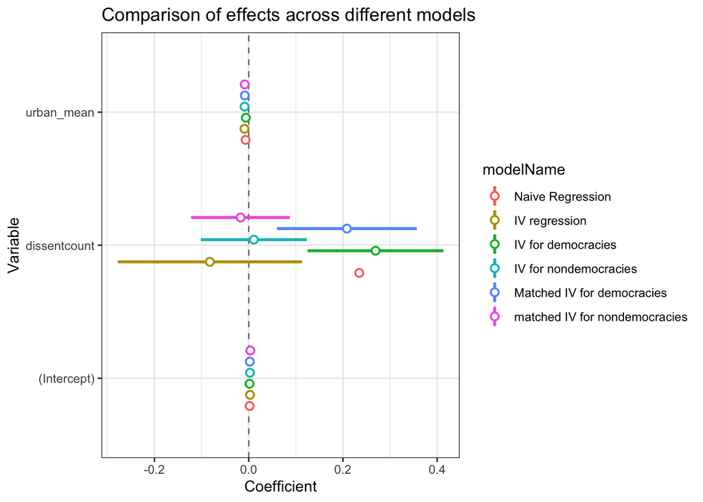

```r
# coefficient plot of final model
#code used and adapted from: https://gist.github.com/dsparks/4332698

#creating different dataframes for all regression models
model1Frame <- data.frame(Variable = rownames(summary(naive_reg)$coef),
                          Coefficient = summary(naive_reg)$coef[, 1],
                          SE = summary(naive_reg)$coef[, 2],
                          modelName = "Naive Regression")
model2Frame <- data.frame(Variable = rownames(summary(iv_regfull)$coef),
                          Coefficient = summary(iv_regfull)$coef[, 1],
                          SE = summary(iv_regfull)$coef[, 2],
                          modelName = "IV regression")
model3Frame <- data.frame(Variable = rownames(summary(iv_dem)$coef),
                          Coefficient = summary(iv_dem)$coef[, 1],
                          SE = summary(iv_dem)$coef[, 2],
                          modelName = "IV for democracies")
model4Frame <- data.frame(Variable = rownames(summary(iv_nondem)$coef),
                          Coefficient = summary(iv_nondem)$coef[, 1],
                          SE = summary(iv_nondem)$coef[, 2],
                          modelName = "IV for nondemocracies")
model5Frame <- data.frame(Variable = rownames(summary(m_dem_reg)$coef),
                          Coefficient = summary(m_dem_reg)$coef[, 1],
                          SE = summary(m_dem_reg)$coef[, 2],
                          modelName = "Matched IV for democracies")
model6Frame <- data.frame(Variable = rownames(summary(m_nondem_reg)$coef),
                          Coefficient = summary(m_nondem_reg)$coef[, 1],
                          SE = summary(m_nondem_reg)$coef[, 2],
                          modelName = "matched IV for nondemocracies")

allModelFrame <- data.frame(rbind(model1Frame, model2Frame, model3Frame, model4Frame, model5Frame, model6Frame))

interval2 <- -qnorm((1-0.95)/2)  # 95% multiplier

coefficient_plot <- ggplot(allModelFrame, aes(colour = modelName))
coefficient_plot <- coefficient_plot + geom_hline(yintercept = 0, colour = gray(1/2), lty = 2)
coefficient_plot <- coefficient_plot + geom_linerange(aes(x = Variable, ymin = Coefficient - SE*interval2,
                                ymax = Coefficient + SE*interval2),
                            lwd = 1, position = position_dodge(width = 1/2))
coefficient_plot <- coefficient_plot + geom_pointrange(aes(x = Variable, y = Coefficient, ymin = Coefficient - SE*interval2,
                                 ymax = Coefficient + SE*interval2),
                             lwd = 1/2, position = position_dodge(width = 1/2),
                             shape = 21, fill = "WHITE")
coefficient_plot <- coefficient_plot + coord_flip() + theme_bw()
coefficient_plot <- coefficient_plot + ggtitle("Comparison of effects across different models")
print(coefficient_plot)  # The trick to these is position_dodge().
```

```r
#code from: https://gist.github.com/dsparks/4332698
```

# 2 Extension Part

## 2.1 Robustness Checks

In spite of its valid research design, the study falls short of both robustness checks and tests of their assumptions on democracy. Those assumptions that are empirically testable, were tested by including a first stage model for each regression. In all cases, the F-statistic confirmed rainfall as a strong instrument (see table 1). However, the authers did not include balance tables to test the usefulness of matching. A first step is therefore to test the covariate balance of both democracies and nondemocracies before and after matching. For this purpose, four balance tables were created. In each table, the pink rows highlight the covariates of interest, and the two columns of difference and percentage difference show the divergence between the split datasets. As can be seen, matching significantly reduced the differences in both datasets for all three covariates of interest. Sometimes, the difference is even close to zero.

### 2.1.1 Balance Tables for Democrcaies

```r
#extension part

#Perform robustness checks:
#balance table before matching (democracies)
set_dem %>%
  select(-date,-adm0_adm1, -dissentcount, -represscount) %>%
  group_by(raintreatment) %>%
  summarise_all(funs(mean(., na.rm = T))) %>% # summarize the mean of every variable
  t() %>% # transpose data
  as.data.frame() %>% # after transposing, convert from matrix to df
  add_rownames("variable") %>% # rownames to explicit column
  rename(no_raintreatment = V1, raintreatment = V2) %>% # rename columns that are created by as.data.frame
  mutate(difference = raintreatment- no_raintreatment,
         differencePerc = difference / (raintreatment + no_raintreatment)) %>%
  mutate_if(is.numeric, round, 3) %>% # round numeric columns
  kable(caption = "TABLE 2: Balance Table of Covariates Across Treatment Variables for Democracies") %>% # create kable table
  row_spec(2, color = "white", background = "purple") %>%
  row_spec(5:7, color = "white", background = "purple") %>%
  kable_styling() # view kable table
```

TABLE 2: Balance Table of Covariates Across Treatment Variables for Democracies

| variable | no_raintreatment | raintreatment | difference | differencePerc |
| --- | --- | --- | --- | --- |
| raintreatment | 0.000 | 1.000 | 1.000 | 1.000 |
| urban_mean | 0.015 | 0.013 | -0.002 | -0.087 |
| lograin | -0.448 | 1.491 | 1.939 | 1.859 |
| rainannualpct | 0.000 | 0.009 | 0.008 | 0.960 |
| latent_democracy | 0.274 | 0.271 | -0.003 | -0.005 |
| pop_sum | 1286876.323 | 1533262.952 | 246386.629 | 0.087 |
| wdi_gdp | 46599447250.036 | 56388519867.977 | 9789072617.940 | 0.095 |

```r
#balance table after matching:
CEM_dem %>%
  select(-date,-adm0_adm1, -dissentcount, -represscount, -distance, -subclass) %>%
  group_by(raintreatment) %>%
  summarise_all(funs(weighted.mean(., weights, na.rm = T))) %>% # summarize the mean of every variable
  t() %>% # transpose data
  as.data.frame() %>% # after transposing, convert from matrix to df
  add_rownames("variable") %>% # rownames to explicit column
  rename(no_raintreatment = V1, raintreatment = V2) %>% # rename columns that are created by as.data.frame
  mutate(difference = raintreatment- no_raintreatment,
         differencePerc = difference / (raintreatment + no_raintreatment)) %>% # create new columns for difference between groups
  mutate_if(is.numeric, round, 3) %>% # round numeric columns
  kable(caption = "TABLE 3:Balance Table of Covariates Across Treatment Variables for Matched Democracies") %>% # create kable table
  row_spec(2, color = "white", background = "purple") %>%
  row_spec(5:7, color = "white", background = "purple") %>%
  kable_styling() # view kable table
```

TABLE 3:Balance Table of Covariates Across Treatment Variables for Matched Democracies

| variable | no_raintreatment | raintreatment | difference | differencePerc |
| --- | --- | --- | --- | --- |
| raintreatment | 0.000 | 1.000 | 1.000 | 1.000 |
| urban_mean | 0.013 | 0.013 | 0.000 | -0.001 |
| lograin | -0.460 | 1.491 | 1.951 | 1.894 |
| rainannualpct | 0.000 | 0.009 | 0.008 | 0.962 |
| latent_democracy | 0.271 | 0.271 | 0.000 | 0.000 |
| pop_sum | 1527491.327 | 1533262.952 | 5771.624 | 0.002 |
| wdi_gdp | 56928702131.521 | 56388519867.977 | -540182263.544 | -0.005 |
| weights | 1.100 | 1.000 | -0.100 | -0.048 |

```r
?kable_styling
```

### 2.1.2 Balance Tables for Nonemocrcaies

```r
  #balance table before matching (nondemocracies)
set_nondem %>%
  select(-date,-adm0_adm1, -dissentcount, -represscount) %>%
  group_by(raintreatment) %>%
  summarise_all(funs(mean(., na.rm = T))) %>% # summarize the mean of every variable
  t() %>% # transpose data
  as.data.frame() %>% # after transposing, convert from matrix to df
  add_rownames("variable") %>% # rownames to explicit column
  rename(no_raintreatment = V1, raintreatment = V2) %>% # rename columns that are created by as.data.frame
  mutate(difference = raintreatment- no_raintreatment,
         differencePerc = difference / (raintreatment + no_raintreatment)) %>% # create new columns for difference between groups
  mutate_if(is.numeric, round, 3) %>% # round numeric columns
  kable(caption = "TABLE 4: Balance Table of Covariates Across Treatment Variables for Nondemocracies", bold = T) %>% # create kable table
  row_spec(2, color = "white", background = "purple") %>%
  row_spec(5:7, color = "white", background = "purple") %>%
  kable_styling() # view kable table
```

TABLE 4: Balance Table of Covariates Across Treatment Variables for Nondemocracies

| variable | no_raintreatment | raintreatment | difference | differencePerc |
| --- | --- | --- | --- | --- |
| raintreatment | 0.000 | 1.000 | 1.000 | 1.000 |
| urban_mean | 0.014 | 0.009 | -0.005 | -0.202 |
| lograin | -0.355 | 1.459 | 1.813 | 1.643 |
| rainannualpct | 0.000 | 0.008 | 0.008 | 0.940 |
| latent_democracy | -0.539 | -0.501 | 0.037 | -0.036 |
| pop_sum | 990342.520 | 1126482.541 | 136140.021 | 0.064 |
| wdi_gdp | 64485510590.633 | 39057736658.313 | -25427773932.319 | -0.246 |

```r
#balance table after matching:
CEM_nondem %>%
  select(-date,-adm0_adm1, -dissentcount, -represscount,-distance, -subclass) %>%
  group_by(raintreatment) %>%
  summarise_all(funs(weighted.mean(.,weights, na.rm = T))) %>% # summarize the mean of every variable
  t() %>% # transpose data
  as.data.frame() %>% # after transposing, convert from matrix to df
  add_rownames("variable") %>% # rownames to explicit column
  rename(no_raintreatment = V1, raintreatment = V2) %>% # rename columns that are created by as.data.frame
  mutate(difference = raintreatment- no_raintreatment,
         differencePerc = difference / (raintreatment + no_raintreatment)) %>% # create new columns for difference between groups
  mutate_if(is.numeric, round, 3) %>% # round numeric columns
  kable(caption = "TABLE 5: Balance Table of Covariates Across Treatment Variables for Matched Nondemocracies") %>% # create kable table
  row_spec(2, color = "white", background = "purple") %>%
  row_spec(5:7, color = "white", background = "purple") %>%
  kable_styling() # view kable table
```

TABLE 5: Balance Table of Covariates Across Treatment Variables for Matched Nondemocracies

| variable | no_raintreatment | raintreatment | difference | differencePerc |
| --- | --- | --- | --- | --- |
| raintreatment | 0.000 | 1.000 | 1.000 | 1.000 |
| urban_mean | 0.009 | 0.009 | 0.000 | -0.014 |
| lograin | -0.380 | 1.459 | 1.839 | 1.704 |
| rainannualpct | 0.000 | 0.008 | 0.008 | 0.954 |
| latent_democracy | -0.516 | -0.501 | 0.015 | -0.015 |
| pop_sum | 1111495.018 | 1126482.541 | 14987.523 | 0.007 |
| wdi_gdp | 38689796721.974 | 39057736658.313 | 367939936.340 | 0.005 |
| weights | 1.295 | 1.000 | -0.295 | -0.129 |

## 2.2 Different Matching method

*Note: This part of the extension was planned, but could not be executed because it exceeded the computational power of my computer. Apparently, propensity score matching takes up a lot of space. I asked Sebastian about the problem and he could not run the code either. He told me it would be best to still include the code, explain what I would have done, and make a comment on the problem. However, I cannot report or analyze the results because I never got there, but I do not epxect great deviations in the final models from the previous matching method.*

A second way to test the validity of the outcome is to use a different way of matching. Here, I chose propensity score matching as it allows us to include more variance among covariates and drop less observations than in exact matching.

### 2.2.1 Matching Data

I first select the variables of interest, perform the matching on both datasets and then merge the two datasets, just as in the orginial study.

```r
#Different way of matching
#test_nondem <- m_nondemocracies %>%
  #select(adm0_adm1, date, dissentcount, represscount, raintreatment, urban_mean, lograin, rainannualpct,
        # latent_democracy,
        # pop_sum, wdi_gdp) %>%
 # na.omit() # %>% pdata.frame(match_data, index=c("adm0_adm1", "date"))

#test_nondem_match <- matchit(raintreatment ~ urban_mean + pop_sum + wdi_gdp,
                    # method = "nearest",
                    # ratio = 1,
                    # replace = TRUE,
                    # data = test_nondem)

#summary(test_nondem_match)

#same for democracies:
#test_dem <- m_democracies %>%
  #select(adm0_adm1, date, dissentcount, represscount, raintreatment, urban_mean, lograin, rainannualpct, latent_democracy,
        # pop_sum, wdi_gdp) %>%
  #na.omit() # %>% pdata.frame(match_data, index=c("adm0_adm1", "date"))

#test_dem_match <- matchit(raintreatment ~ urban_mean + pop_sum + wdi_gdp,
                    # method = "nearest",
                   #  ratio = 1,
                    # replace = TRUE,
                    # data = test_dem)

#summary(test_dem_match)

#joining datasets:
#test_nondem_weights <- full_join(test_nondem, test_nondem_match, by = NULL)
#test_dem_weights <- full_join(test_dem, test_dem_match, by = NULL)
```

### 2.2.2 Regression on Matched Dataset

I then run the regression model on the new matched datasets.

```r
#perform regression on nondems:
#test_nondem_reg <- ivreg(represscount ~ dissentcount + urban_mean | lograin + rainannualpct + urban_mean, data = nondem_weights, weights = test_nondem_weights$weights)

#first stage:
#test_nondem_firststage <- lm(dissentcount ~ lograin + rainannualpct + urban_mean, data = nondem_weights, weights = test_nondem_weights$weights)

#perform regression on dems:
#test_dem_reg <- ivreg(represscount ~ dissentcount + urban_mean | lograin + rainannualpct + urban_mean, data = dem_weights, weights = test_dem_weights$weights)

#first stage:
#test_dem_firststage <- lm(dissentcount ~ lograin + rainannualpct + urban_mean, data = dem_weights, weights = test_dem_weights$weights)
```

### 2.2.3 Matching Results

The table should show the results of the two new models by regressing repression on dissent in differently matched datasets.

```r
#stargazer  (test_nondem_firststage,test_nondem_reg,test_dem_firststage,test_dem_reg,
          # title="TABLE 6. The Effect of Mobilized Dissent on State Repression: Propensity Score Matching",
          # out="raintable_test.html",
          # digits = 3,
           #covariate.labels=c("Mobilized Dissent", "Rainfall (Ln)", "Annual Rainfall", "Urbanization",
                            #  "Constant"),
          # column.labels=c("Matched nondemocracies","Matched democrcaies"),
          # column.separate = c(2, 2),
          # dep.var.labels = c("Stage 1", "Stage 2", "Stage 1", "Stage 2"),
          # model.names = FALSE, keep.stat = ("f", "n", "adj.rsq","rsq"),
          # align=TRUE)
```

## 2.3 Investigating democracy

### 2.3.1 An RDD Design

Lastly, and most importantly, by splitting the dataset into democracies and nondemocracies, the authors make huge assumptions about a binary switch from preventive repression to no preventive repression. Even though the narrative is reasonable – in a democracy with secured human rights, abusive measures to prevent freedom of speech are harder or even impossible to achieve – one should be wary to treat an elusive and multi-dimensional concept such as democracy in such a simplified way. The dataset includes the variable latent_democracy as a non-binary variable with a linear score. This more nuanced score allows us to test whether there is, in fact, a jump at the threshold of 0. Therefore, to test whether the binary distinction makes sense, I conducted an RDD analysis of the effect of democracy on dissent. The hypothesis is that dissent should less likely occur in non-democracies than in democracies and show a jump at the threshold of 0, where we assume a state to switch from a nondemocracy to a democracy. I thereby assume a linear trend, but I do not assume the same slope on both sides because it is not plausible that dissent should increase similarly steeply as before once a certain level of democratic rights is secure.

### 2.3.2 Visual Representation

I start with a visualization of the assumption and create a scatterplot showing democracy as a forcing variable and dissent as the outcome variable. The cutpoint, as the study suggests, is set at 0.

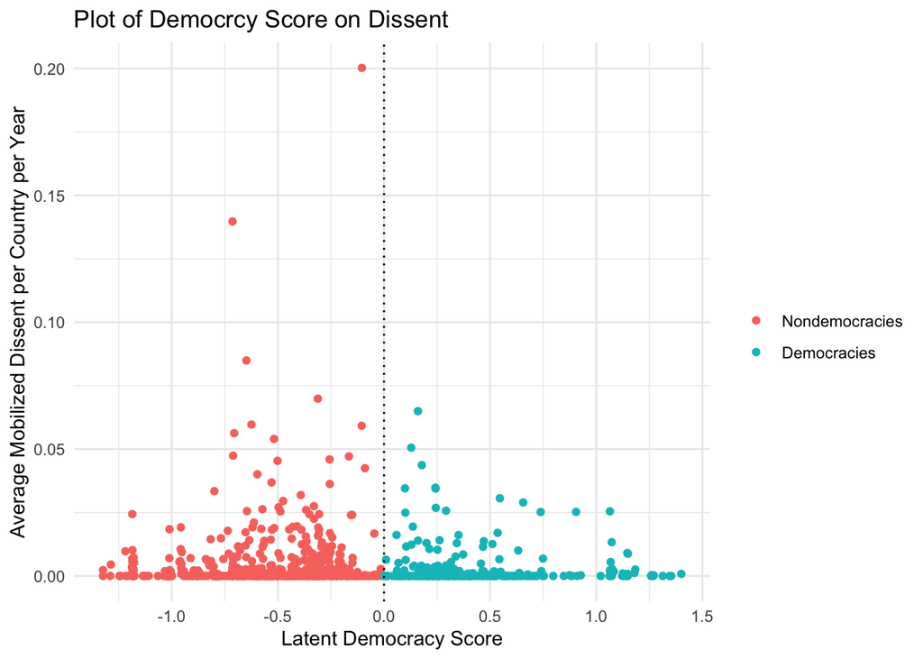

```r
#looking at RDD: latent_democracy as forcing variable, dissent as outcome variable:
# plot:

#choosing  visual bandwidth:

small_regdata <- regdata %>%
  group_by(adm0_name,year) %>%
  summarise(latdem_mean=mean(latent_democracy),dissent_mean=mean(dissentcount)) %>%
  mutate(democracy=ifelse(latdem_mean<=0, 0, 1))%>%
  na.omit()
#plot
ggplot(small_regdata) +
  geom_point(aes(x = latdem_mean,
           y = dissent_mean,
           color = factor(democracy))) +
  geom_vline(xintercept = 0, linetype = "dotted") +
     labs(title = "Plot of Democrcy Score on Dissent",
       x = "Latent Democracy Score",
       y = "Average Mobilized Dissent per Country per Year") +
    scale_color_manual(name = "",
                     values = c("#F8766D", "#00BFC4"),
                     labels = c("Nondemocracies", "Democracies")) +
  theme_minimal()
```

### 2.3.3 Calculation

```r
#RDD calculation:
democracy_rdd <- RDestimate(dissentcount ~ latent_democracy + urban_mean, data = regdata, cutpoint = 0)
summary(democracy_rdd)
```

```
##
## Call:
## RDestimate(formula = dissentcount ~ latent_democracy + urban_mean,
##     data = regdata, cutpoint = 0)
##
## Type:
## fuzzy
##
## Estimates:
##            Bandwidth  Observations  Estimate  Std. Error  z value
## LATE       0.04433    148259        -0.10692  0.01888     -5.663
## Half-BW    0.02217    102212        -0.08778  0.02380     -3.689
## Double-BW  0.08866    456675        -0.17015  0.04299     -3.958
##            Pr(>|z|)
## LATE       0.00000001489  ***
## Half-BW    0.00022556309  ***
## Double-BW  0.00007563415  ***
## ---
## Signif. codes:  0 '***' 0.001 '**' 0.01 '*' 0.05 '.' 0.1 ' ' 1
##
## F-statistics:
##            F      Num. DoF  Denom. DoF  p
## LATE       16.08  3         148255      0.0000000001902885
## Half-BW    20.11  3         102208      0.0000000000005077
## Double-BW  21.94  3         456671      0.0000000000000336
```

```r
#robustness check:
robust_rdd <- RDestimate(dissentcount ~ latent_democracy + urban_mean, data = regdata, cutpoint = 0.5)
summary(robust_rdd)
```

```
##
## Call:
## RDestimate(formula = dissentcount ~ latent_democracy + urban_mean,
##     data = regdata, cutpoint = 0.5)
##
## Type:
## fuzzy
##
## Estimates:
##            Bandwidth  Observations  Estimate  Std. Error  z value
## LATE       0.15894    397073        -0.49084  0.07861     -6.244
## Half-BW    0.07947    185572        -0.09668  0.02293     -4.217
## Double-BW  0.31788    881746        -0.43295  0.06620     -6.540
##            Pr(>|z|)
## LATE       0.00000000042751  ***
## Half-BW    0.00002475680790  ***
## Double-BW  0.00000000006152  ***
## ---
## Signif. codes:  0 '***' 0.001 '**' 0.01 '*' 0.05 '.' 0.1 ' ' 1
##
## F-statistics:
##            F      Num. DoF  Denom. DoF
## LATE       36.03  3         397069
## Half-BW    51.38  3         185568
## Double-BW  66.36  3         881742
##            p
## LATE       0.0000000000000000000000284731309896828991025942
## Half-BW    0.0000000000000000000000000000000034860464060881
## Double-BW  0.0000000000000000000000000000000000000000006742
```

### 2.3.4 RDD Plots

In a second step, I visualize to demonstrate the calculated LATE:

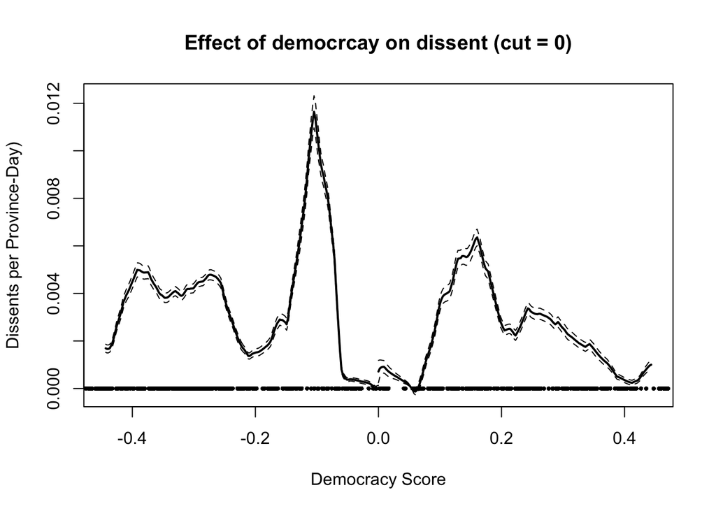

```r
#Plotting the results:
plot(democracy_rdd)
title(main = "Effect of democrcay on dissent (cut = 0)", xlab = "Democracy Score", ylab = "Dissents per Province-Day)")
```

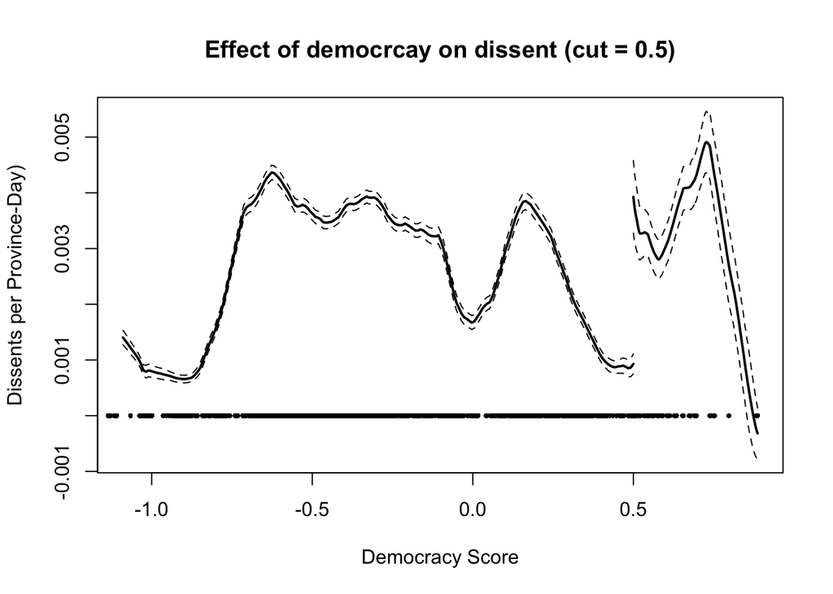

```r
plot(robust_rdd)
title(main = "Effect of democrcay on dissent (cut = 0.5)", xlab = "Democracy Score", ylab = "Dissents per Province-Day)")
```